```python
# mounting the drive
from google.colab import drive
drive.mount('/content/drive', force_remount=True)
```

```python
!pip install tensorflow
import numpy as np
import matplotlib.pyplot as plt
from sklearn.model_selection import train_test_split
from sklearn.decomposition import PCA
from sklearn.manifold import TSNE
from sklearn.cluster import KMeans
import tensorflow as tf
from tensorflow.keras import layers, Model
```

# Part 1: Data Visualization [1 pts]

1. Download the data. Load and standardize the images using min-max normalization. Use an 80%-20% split of the data for training and testing in this assignment.
2. Use visualization to explore the images.

```python
data = np.load("/content/drive/My Drive/QBIO465/xray_images.npz")
images = data['images'].astype(np.float32)

# min/max normalization
images = (images - images.min()) / (images.max() - images.min())

# training/testing split
x_train, x_test = train_test_split(images, test_size=0.2, random_state=42)
```

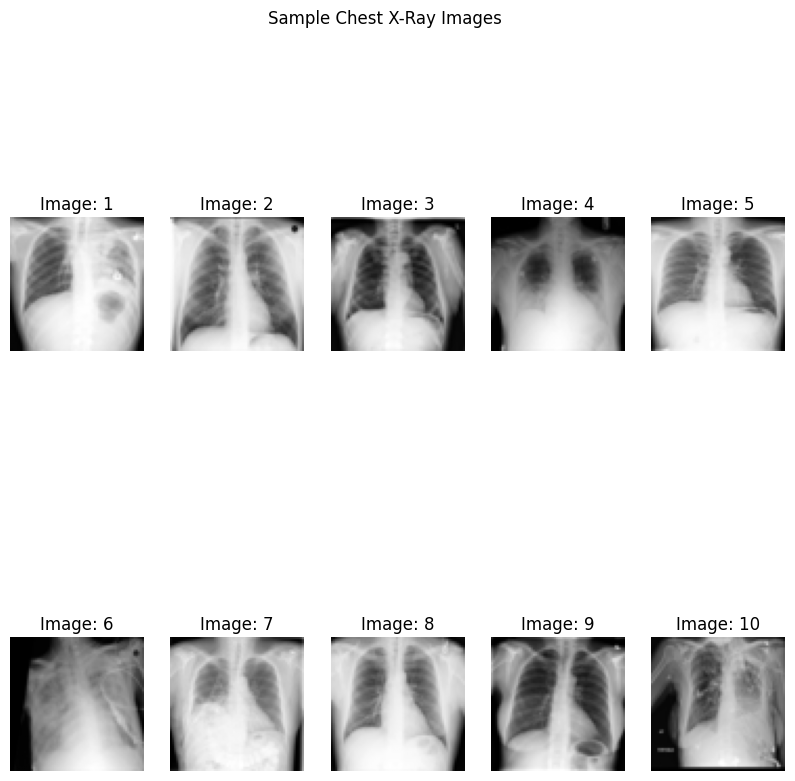

```python
# visualization
plt.figure(figsize=(10, 10))
for i in range(10):
  plt.subplot(2, 5, i + 1)
  plt.imshow(x_train[i], cmap='gray')
  plt.axis('off')
  plt.title(f"Image: {i+1}")
plt.suptitle("Sample Chest X-Ray Images")
plt.show()
```

What differences do you notice between the images?  
Some are cloudy while others are clear, one possibly has a tumor? Different anatomies also.

# Part 2: Generative Variational Autoencoder [2 pts]

• Train a convolutional variational autoencoder to learn a low-dimensional representation of the data.  
• Use three different latent space sizes: 4, 16, and 32 (i.e., build separate models).  
• Use two a two-term loss function:  
Reconstruction loss: Binary Cross Entropy between each pixel of the input and reconstructed images.

- Kullback-Leibler (KL) loss: KL divergence between the latent distribution and a standard normal distribution.
- Train the model for at least 100 epochs (adjust as needed for optimal results).
- Report the training and testing history plots.  
  Hints:  
  ● Use a symmetric encoder-decoder architecture.  
  ● Use Conv2D with stride=2 for each encoder layer, and Conv2DTranspose with stride=2 for each decoder layer  
  ● Do not use activation functions in the input, latent, or output layers.

```python
def build_encoder(latent_dim):
    inputs = layers.Input(shape=(x_train.shape[1], x_train.shape[2], 1))
    x = layers.Conv2D(32, 3, activation='relu', strides=2, padding='same')(inputs)
    x = layers.Conv2D(64, 3, activation='relu', strides=2, padding='same')(x)
    x = layers.Flatten()(x)
    x = layers.Dense(128, activation='relu')(x)

    z_mean = layers.Dense(latent_dim, name='z_mean')(x)
    z_log_var = layers.Dense(latent_dim, name='z_log_var')(x)

    # Reparameterization trick
    def sampling(args):
        z_mean, z_log_var = args
        epsilon = tf.random.normal(shape=(tf.shape(z_mean)[0], latent_dim))
        return z_mean + tf.exp(0.5 * z_log_var) * epsilon

    z = layers.Lambda(sampling)([z_mean, z_log_var])
    return Model(inputs, [z_mean, z_log_var, z], name="encoder")
```

```python
def build_decoder(latent_dim):
  latent_inputs = layers.Input(shape=(latent_dim,))
  x = layers.Dense(16 * 16 * 64, activation='relu')(latent_inputs)
  x = layers.Reshape((16, 16,64))(x)
  x = layers.Conv2DTranspose(64, 3, activation='relu', strides=2, padding='same')(x)
  x = layers.Conv2DTranspose(32, 3, activation='relu', strides=2, padding='same')(x)
  outputs = layers.Conv2DTranspose(1, 3, activation='sigmoid', padding='same')(x)
  return Model(latent_inputs, outputs, name="decoder")
```

```python
class VAE(Model):
    def __init__(self, encoder, decoder, **kwargs):
        super(VAE, self).__init__(**kwargs)
        self.encoder = encoder
        self.decoder = decoder

    def compile(self, optimizer):
        super().compile(optimizer=optimizer, loss=self.dummy_loss)
        self.optimizer = optimizer
        self.bce_loss = tf.keras.losses.BinaryCrossentropy()

    def dummy_loss(self, y_true, y_pred):
        return tf.constant(0.0)

    def train_step(self, data):
        if isinstance(data, tuple):
            data = data[0]
        with tf.GradientTape() as tape:
            z_mean, z_log_var, z = self.encoder(data)
            reconstruction = self.decoder(z)
            reconstruction_loss = self.bce_loss(data, reconstruction)
            kl_loss = -0.5 * tf.reduce_mean(
                1 + z_log_var - tf.square(z_mean) - tf.exp(z_log_var)
            )
            total_loss = reconstruction_loss + kl_loss
        grads = tape.gradient(total_loss, self.trainable_weights)
        self.optimizer.apply_gradients(zip(grads, self.trainable_weights))
        return {
            "loss": total_loss,
            "reconstruction_loss": reconstruction_loss,
            "kl_loss": kl_loss
        }

    def call(self, inputs):
        z_mean, z_log_var, z = self.encoder(inputs)
        return self.decoder(z)
```

```python
x_train_exp = np.expand_dims(x_train, -1)
x_test_exp = np.expand_dims(x_test, -1)

def train_vae(latent_dim):
  encoder = build_encoder(latent_dim)
  decoder = build_decoder(latent_dim)
  vae = VAE(encoder, decoder)
  vae.compile(optimizer=tf.keras.optimizers.Adam())

  history = vae.fit(
    x_train_exp, x_train_exp,  # both input and target are the image
    epochs=100,
    batch_size=64,
    validation_data=(x_test_exp, x_test_exp)
  )
  return vae, history
```

# Part 3: Visualize Reconstruction and PCA/t-SNE [2 pts]

## For each model from Part 2:

- Visualize the original image vs. reconstructed image for 10 images from the test dataset.
- Randomly sample 1000 images from the training dataset and encode each one into its latent vector.
- Cluster the vectors (K-means clustering) and visualize images from a few of the clusters.
- Perform PCA and t-SNE on these latent vectors and make plots visualizing the distribution of the images for the first two dimensions, coloring points by cluster.

```python
def show_reconstruction(vae, x_test_exp, n=10):
  decoded = vae.decoder(vae.encoder(x_test_exp[:n])[2])
  decoded = decoded.numpy()

  plt.figure(figsize=(20, 4))
  for i in range(n):
    # OG
    plt.subplot(2, n, i + 1)
    plt.imshow(x_test_exp[i].squeeze(), cmap='gray')
    plt.axis('off')
    # reconstruction
    plt.subplot(2, n, i + n + 1)
    plt.imshow(decoded[i].squeeze(), cmap='gray')
    plt.axis('off')
  plt.suptitle("Original vs Reconstructed")
  plt.show()
```

[output not shown]

```python
def extract_latents(vae, x_train_exp, n_samples=1000):
  x_sample = x_train_exp[:n_samples]
  z_mean, _, _ = vae.encoder(x_sample)
  return z_mean.numpy()

def cluster_latents(latents, n_clusters=5):
  kmeans = KMeans(n_clusters=n_clusters, random_state=0)
  labels = kmeans.fit_predict(latents)
  return labels, kmeans
```

```python
def visualize_latent_space(latents, labels, method='pca'):
  if method == 'pca':
    reduced = PCA(n_components=2).fit_transform(latents)
  elif method == 'tsne':
    reduced = TSNE(n_components=2, perplexity=30).fit_transform(latents)
  else:
    raise ValueError("Choose 'pca' or 'tsne'.")

  plt.figure(figsize=(10, 8))
  plt.scatter(reduced[:, 0], reduced[:, 1], c=labels, cmap='tab10', s=10)
  plt.title(f"{method.upper()} of Latent Space")
  plt.xlabel("Component 1")
  plt.ylabel("Component 2")
  plt.colorbar(label='Cluster ID')
  plt.show()
```

```
141/141 ━━━━━━━━━━━━━━━━━━━━ 75s 508ms/step - kl_loss: 0.0041 - loss: 0.6552 - reconstruction_loss: 0.6510 - val_loss: 0.0000e+00
141/141 ━━━━━━━━━━━━━━━━━━━━ 81s 501ms/step - kl_loss: 1.3131e-06 - loss: 0.6338 - reconstruction_loss: 0.6338 - val_loss: 0.0000e+00
141/141 ━━━━━━━━━━━━━━━━━━━━ 102s 646ms/step - kl_loss: 1.5063e-06 - loss: 0.6335 - reconstruction_loss: 0.6335 - val_loss: 0.0000e+00
141/141 ━━━━━━━━━━━━━━━━━━━━ 123s 508ms/step - kl_loss: 1.1763e-06 - loss: 0.6333 - reconstruction_loss: 0.6333 - val_loss: 0.0000e+00
141/141 ━━━━━━━━━━━━━━━━━━━━ 71s 501ms/step - kl_loss: 2.0708e-06 - loss: 0.6331 - reconstruction_loss: 0.6331 - val_loss: 0.0000e+00
141/141 ━━━━━━━━━━━━━━━━━━━━ 80s 490ms/step - kl_loss: 7.1906e-07 - loss: 0.6331 - reconstruction_loss: 0.6331 - val_loss: 0.0000e+00
141/141 ━━━━━━━━━━━━━━━━━━━━ 69s 490ms/step - kl_loss: 3.8478e-07 - loss: 0.6332 - reconstruction_loss: 0.6332 - val_loss: 0.0000e+00
141/141 ━━━━━━━━━━━━━━━━━━━━ 69s 490ms/step - kl_loss: 2.3451e-06 - loss: 0.6332 - reconstruction_loss: 0.6332 - val_loss: 0.0000e+00
141/141 ━━━━━━━━━━━━━━━━━━━━ 83s 500ms/step - kl_loss: 5.1419e-07 - loss: 0.6329 - reconstruction_loss: 0.6329 - val_loss: 0.0000e+00
141/141 ━━━━━━━━━━━━━━━━━━━━ 79s 483ms/step - kl_loss: 1.1699e-06 - loss: 0.6331 - reconstruction_loss: 0.6331 - val_loss: 0.0000e+00
141/141 ━━━━━━━━━━━━━━━━━━━━ 82s 482ms/step - kl_loss: 7.9202e-07 - loss: 0.6329 - reconstruction_loss: 0.6329 - val_loss: 0.0000e+00
141/141 ━━━━━━━━━━━━━━━━━━━━ 69s 489ms/step - kl_loss: 1.5660e-06 - loss: 0.6328 - reconstruction_loss: 0.6328 - val_loss: 0.0000e+00
141/141 ━━━━━━━━━━━━━━━━━━━━ 69s 490ms/step - kl_loss: 3.8582e-07 - loss: 0.6331 - reconstruction_loss: 0.6331 - val_loss: 0.0000e+00
141/141 ━━━━━━━━━━━━━━━━━━━━ 82s 492ms/step - kl_loss: 1.1915e-06 - loss: 0.6329 - reconstruction_loss: 0.6329 - val_loss: 0.0000e+00
141/141 ━━━━━━━━━━━━━━━━━━━━ 69s 490ms/step - kl_loss: 4.9122e-07 - loss: 0.6328 - reconstruction_loss: 0.6328 - val_loss: 0.0000e+00
141/141 ━━━━━━━━━━━━━━━━━━━━ 82s 490ms/step - kl_loss: 5.0458e-07 - loss: 0.6329 - reconstruction_loss: 0.6329 - val_loss: 0.0000e+00
141/141 ━━━━━━━━━━━━━━━━━━━━ 69s 489ms/step - kl_loss: 7.0972e-07 - loss: 0.6328 - reconstruction_loss: 0.6328 - val_loss: 0.0000e+00
141/141 ━━━━━━━━━━━━━━━━━━━━ 81s 482ms/step - kl_loss: 1.1196e-07 - loss: 0.6328 - reconstruction_loss: 0.6328 - val_loss: 0.0000e+00
141/141 ━━━━━━━━━━━━━━━━━━━━ 82s 479ms/step - kl_loss: 7.7477e-08 - loss: 0.6329 - reconstruction_loss: 0.6329 - val_loss: 0.0000e+00
141/141 ━━━━━━━━━━━━━━━━━━━━ 82s 480ms/step - kl_loss: 8.6508e-07 - loss: 0.6330 - reconstruction_loss: 0.6330 - val_loss: 0.0000e+00
141/141 ━━━━━━━━━━━━━━━━━━━━ 82s 480ms/step - kl_loss: 1.4354e-06 - loss: 0.6328 - reconstruction_loss: 0.6328 - val_loss: 0.0000e+00
141/141 ━━━━━━━━━━━━━━━━━━━━ 82s 481ms/step - kl_loss: 4.5107e-07 - loss: 0.6329 - reconstruction_loss: 0.6329 - val_loss: 0.0000e+00
141/141 ━━━━━━━━━━━━━━━━━━━━ 82s 480ms/step - kl_loss: 1.5869e-06 - loss: 0.6328 - reconstruction_loss: 0.6328 - val_loss: 0.0000e+00
141/141 ━━━━━━━━━━━━━━━━━━━━ 82s 478ms/step - kl_loss: 1.1126e-06 - loss: 0.6328 - reconstruction_loss: 0.6328 - val_loss: 0.0000e+00
141/141 ━━━━━━━━━━━━━━━━━━━━ 82s 478ms/step - kl_loss: 2.0232e-06 - loss: 0.6331 - reconstruction_loss: 0.6331 - val_loss: 0.0000e+00
141/141 ━━━━━━━━━━━━━━━━━━━━ 82s 481ms/step - kl_loss: 1.8437e-06 - loss: 0.6331 - reconstruction_loss: 0.6331 - val_loss: 0.0000e+00
141/141 ━━━━━━━━━━━━━━━━━━━━ 82s 481ms/step - kl_loss: 8.1405e-07 - loss: 0.6328 - reconstruction_loss: 0.6328 - val_loss: 0.0000e+00
141/141 ━━━━━━━━━━━━━━━━━━━━ 82s 480ms/step - kl_loss: 1.7628e-06 - loss: 0.6329 - reconstruction_loss: 0.6329 - val_loss: 0.0000e+00
141/141 ━━━━━━━━━━━━━━━━━━━━ 82s 481ms/step - kl_loss: 1.2413e-06 - loss: 0.6330 - reconstruction_loss: 0.6330 - val_loss: 0.0000e+00
141/141 ━━━━━━━━━━━━━━━━━━━━ 69s 487ms/step - kl_loss: 1.1735e-06 - loss: 0.6331 - reconstruction_loss: 0.6331 - val_loss: 0.0000e+00
141/141 ━━━━━━━━━━━━━━━━━━━━ 82s 491ms/step - kl_loss: 2.1787e-06 - loss: 0.6328 - reconstruction_loss: 0.6328 - val_loss: 0.0000e+00
141/141 ━━━━━━━━━━━━━━━━━━━━ 69s 492ms/step - kl_loss: 1.3170e-06 - loss: 0.6328 - reconstruction_loss: 0.6328 - val_loss: 0.0000e+00
141/141 ━━━━━━━━━━━━━━━━━━━━ 69s 492ms/step - kl_loss: 1.3465e-06 - loss: 0.6327 - reconstruction_loss: 0.6327 - val_loss: 0.0000e+00
141/141 ━━━━━━━━━━━━━━━━━━━━ 82s 491ms/step - kl_loss: 1.0792e-06 - loss: 0.6329 - reconstruction_loss: 0.6329 - val_loss: 0.0000e+00
141/141 ━━━━━━━━━━━━━━━━━━━━ 83s 496ms/step - kl_loss: 1.7009e-06 - loss: 0.6328 - reconstruction_loss: 0.6328 - val_loss: 0.0000e+00
141/141 ━━━━━━━━━━━━━━━━━━━━ 69s 492ms/step - kl_loss: 1.5544e-06 - loss: 0.6328 - reconstruction_loss: 0.6328 - val_loss: 0.0000e+00
141/141 ━━━━━━━━━━━━━━━━━━━━ 81s 485ms/step - kl_loss: 1.0926e-06 - loss: 0.6328 - reconstruction_loss: 0.6328 - val_loss: 0.0000e+00
141/141 ━━━━━━━━━━━━━━━━━━━━ 82s 489ms/step - kl_loss: 1.4891e-06 - loss: 0.6328 - reconstruction_loss: 0.6328 - val_loss: 0.0000e+00
141/141 ━━━━━━━━━━━━━━━━━━━━ 71s 503ms/step - kl_loss: 8.3084e-07 - loss: 0.6326 - reconstruction_loss: 0.6326 - val_loss: 0.0000e+00
141/141 ━━━━━━━━━━━━━━━━━━━━ 69s 493ms/step - kl_loss: 1.7839e-07 - loss: 0.6330 - reconstruction_loss: 0.6330 - val_loss: 0.0000e+00
```

[output cut: 45 more lines]

```
141/141 ━━━━━━━━━━━━━━━━━━━━ 82s 492ms/step - kl_loss: 2.0419e-06 - loss: 0.6329 - reconstruction_loss: 0.6329 - val_loss: 0.0000e+00
141/141 ━━━━━━━━━━━━━━━━━━━━ 69s 487ms/step - kl_loss: 9.3065e-07 - loss: 0.6327 - reconstruction_loss: 0.6327 - val_loss: 0.0000e+00
141/141 ━━━━━━━━━━━━━━━━━━━━ 68s 483ms/step - kl_loss: 1.3263e-06 - loss: 0.6327 - reconstruction_loss: 0.6327 - val_loss: 0.0000e+00
141/141 ━━━━━━━━━━━━━━━━━━━━ 69s 492ms/step - kl_loss: 2.2006e-06 - loss: 0.6327 - reconstruction_loss: 0.6327 - val_loss: 0.0000e+00
141/141 ━━━━━━━━━━━━━━━━━━━━ 69s 491ms/step - kl_loss: 1.3057e-06 - loss: 0.6327 - reconstruction_loss: 0.6327 - val_loss: 0.0000e+00
141/141 ━━━━━━━━━━━━━━━━━━━━ 69s 491ms/step - kl_loss: 5.8044e-07 - loss: 0.6329 - reconstruction_loss: 0.6329 - val_loss: 0.0000e+00
141/141 ━━━━━━━━━━━━━━━━━━━━ 82s 492ms/step - kl_loss: 1.3242e-06 - loss: 0.6328 - reconstruction_loss: 0.6328 - val_loss: 0.0000e+00
141/141 ━━━━━━━━━━━━━━━━━━━━ 69s 488ms/step - kl_loss: 1.3126e-06 - loss: 0.6328 - reconstruction_loss: 0.6328 - val_loss: 0.0000e+00
141/141 ━━━━━━━━━━━━━━━━━━━━ 82s 492ms/step - kl_loss: 1.1404e-06 - loss: 0.6330 - reconstruction_loss: 0.6330 - val_loss: 0.0000e+00
141/141 ━━━━━━━━━━━━━━━━━━━━ 68s 483ms/step - kl_loss: 1.4931e-06 - loss: 0.6326 - reconstruction_loss: 0.6326 - val_loss: 0.0000e+00
141/141 ━━━━━━━━━━━━━━━━━━━━ 69s 491ms/step - kl_loss: 1.1500e-06 - loss: 0.6328 - reconstruction_loss: 0.6328 - val_loss: 0.0000e+00
141/141 ━━━━━━━━━━━━━━━━━━━━ 82s 491ms/step - kl_loss: 1.8954e-06 - loss: 0.6330 - reconstruction_loss: 0.6330 - val_loss: 0.0000e+00
141/141 ━━━━━━━━━━━━━━━━━━━━ 69s 491ms/step - kl_loss: 7.3116e-07 - loss: 0.6328 - reconstruction_loss: 0.6328 - val_loss: 0.0000e+00
141/141 ━━━━━━━━━━━━━━━━━━━━ 82s 494ms/step - kl_loss: 5.0198e-07 - loss: 0.6328 - reconstruction_loss: 0.6328 - val_loss: 0.0000e+00
141/141 ━━━━━━━━━━━━━━━━━━━━ 69s 492ms/step - kl_loss: 3.6665e-06 - loss: 0.6326 - reconstruction_loss: 0.6326 - val_loss: 0.0000e+00
```

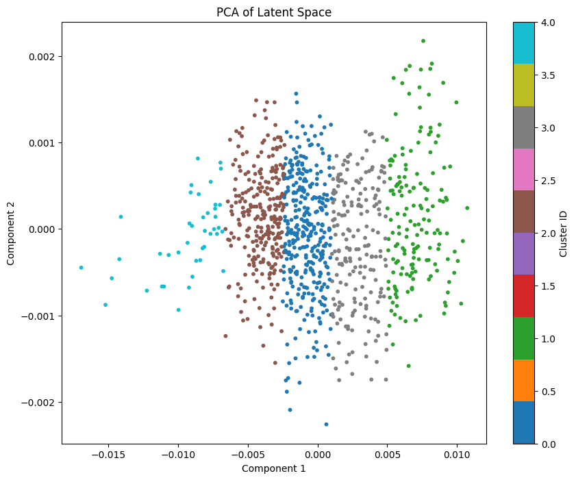

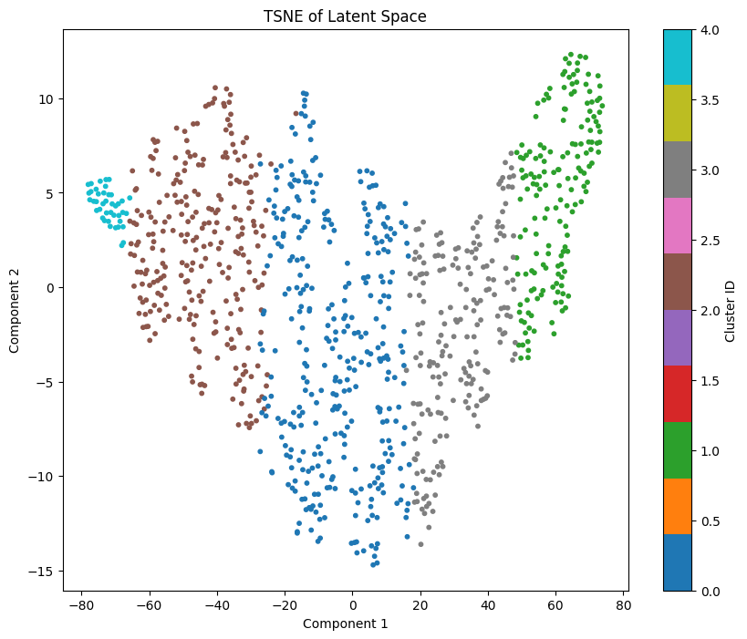

```python
# testing
vae_4, _ = train_vae(4)
latents_4 = extract_latents(vae_4, x_train_exp)
labels_4, _ = cluster_latents(latents_4)
visualize_latent_space(latents_4, labels_4, method='pca')
visualize_latent_space(latents_4, labels_4, method='tsne')
```

```
141/141 ━━━━━━━━━━━━━━━━━━━━ 77s 513ms/step - kl_loss: 0.0011 - loss: 0.6487 - reconstruction_loss: 0.6476 - val_loss: 0.0000e+00
141/141 ━━━━━━━━━━━━━━━━━━━━ 81s 505ms/step - kl_loss: 5.8772e-05 - loss: 0.6345 - reconstruction_loss: 0.6344 - val_loss: 0.0000e+00
141/141 ━━━━━━━━━━━━━━━━━━━━ 81s 503ms/step - kl_loss: 7.1714e-05 - loss: 0.6339 - reconstruction_loss: 0.6338 - val_loss: 0.0000e+00
141/141 ━━━━━━━━━━━━━━━━━━━━ 72s 511ms/step - kl_loss: 4.7104e-05 - loss: 0.6340 - reconstruction_loss: 0.6340 - val_loss: 0.0000e+00
141/141 ━━━━━━━━━━━━━━━━━━━━ 83s 516ms/step - kl_loss: 5.1207e-05 - loss: 0.6336 - reconstruction_loss: 0.6335 - val_loss: 0.0000e+00
141/141 ━━━━━━━━━━━━━━━━━━━━ 81s 513ms/step - kl_loss: 3.7636e-05 - loss: 0.6332 - reconstruction_loss: 0.6332 - val_loss: 0.0000e+00
141/141 ━━━━━━━━━━━━━━━━━━━━ 73s 518ms/step - kl_loss: 4.8644e-05 - loss: 0.6336 - reconstruction_loss: 0.6335 - val_loss: 0.0000e+00
141/141 ━━━━━━━━━━━━━━━━━━━━ 80s 507ms/step - kl_loss: 2.9395e-05 - loss: 0.6334 - reconstruction_loss: 0.6334 - val_loss: 0.0000e+00
141/141 ━━━━━━━━━━━━━━━━━━━━ 83s 513ms/step - kl_loss: 1.8991e-05 - loss: 0.6333 - reconstruction_loss: 0.6332 - val_loss: 0.0000e+00
141/141 ━━━━━━━━━━━━━━━━━━━━ 71s 503ms/step - kl_loss: 2.0796e-05 - loss: 0.6331 - reconstruction_loss: 0.6330 - val_loss: 0.0000e+00
141/141 ━━━━━━━━━━━━━━━━━━━━ 70s 500ms/step - kl_loss: 2.1076e-05 - loss: 0.6333 - reconstruction_loss: 0.6333 - val_loss: 0.0000e+00
141/141 ━━━━━━━━━━━━━━━━━━━━ 83s 511ms/step - kl_loss: 1.9043e-05 - loss: 0.6333 - reconstruction_loss: 0.6332 - val_loss: 0.0000e+00
141/141 ━━━━━━━━━━━━━━━━━━━━ 72s 509ms/step - kl_loss: 2.2267e-05 - loss: 0.6330 - reconstruction_loss: 0.6329 - val_loss: 0.0000e+00
141/141 ━━━━━━━━━━━━━━━━━━━━ 83s 512ms/step - kl_loss: 2.6619e-05 - loss: 0.6332 - reconstruction_loss: 0.6332 - val_loss: 0.0000e+00
141/141 ━━━━━━━━━━━━━━━━━━━━ 81s 506ms/step - kl_loss: 2.2447e-05 - loss: 0.6330 - reconstruction_loss: 0.6330 - val_loss: 0.0000e+00
141/141 ━━━━━━━━━━━━━━━━━━━━ 83s 512ms/step - kl_loss: 1.1610e-05 - loss: 0.6330 - reconstruction_loss: 0.6330 - val_loss: 0.0000e+00
141/141 ━━━━━━━━━━━━━━━━━━━━ 72s 511ms/step - kl_loss: 1.0163e-05 - loss: 0.6331 - reconstruction_loss: 0.6331 - val_loss: 0.0000e+00
141/141 ━━━━━━━━━━━━━━━━━━━━ 82s 512ms/step - kl_loss: 1.1115e-05 - loss: 0.6330 - reconstruction_loss: 0.6330 - val_loss: 0.0000e+00
141/141 ━━━━━━━━━━━━━━━━━━━━ 81s 509ms/step - kl_loss: 1.7011e-05 - loss: 0.6332 - reconstruction_loss: 0.6332 - val_loss: 0.0000e+00
141/141 ━━━━━━━━━━━━━━━━━━━━ 72s 513ms/step - kl_loss: 1.4019e-05 - loss: 0.6331 - reconstruction_loss: 0.6331 - val_loss: 0.0000e+00
141/141 ━━━━━━━━━━━━━━━━━━━━ 82s 512ms/step - kl_loss: 2.1125e-05 - loss: 0.6331 - reconstruction_loss: 0.6331 - val_loss: 0.0000e+00
141/141 ━━━━━━━━━━━━━━━━━━━━ 82s 514ms/step - kl_loss: 2.4387e-05 - loss: 0.6331 - reconstruction_loss: 0.6331 - val_loss: 0.0000e+00
141/141 ━━━━━━━━━━━━━━━━━━━━ 72s 512ms/step - kl_loss: 1.4125e-05 - loss: 0.6333 - reconstruction_loss: 0.6333 - val_loss: 0.0000e+00
141/141 ━━━━━━━━━━━━━━━━━━━━ 82s 508ms/step - kl_loss: 2.2779e-05 - loss: 0.6330 - reconstruction_loss: 0.6330 - val_loss: 0.0000e+00
141/141 ━━━━━━━━━━━━━━━━━━━━ 81s 505ms/step - kl_loss: 2.4062e-05 - loss: 0.6329 - reconstruction_loss: 0.6329 - val_loss: 0.0000e+00
141/141 ━━━━━━━━━━━━━━━━━━━━ 82s 511ms/step - kl_loss: 2.2817e-05 - loss: 0.6331 - reconstruction_loss: 0.6331 - val_loss: 0.0000e+00
141/141 ━━━━━━━━━━━━━━━━━━━━ 82s 514ms/step - kl_loss: 1.3408e-05 - loss: 0.6331 - reconstruction_loss: 0.6331 - val_loss: 0.0000e+00
141/141 ━━━━━━━━━━━━━━━━━━━━ 81s 508ms/step - kl_loss: 1.1492e-05 - loss: 0.6331 - reconstruction_loss: 0.6330 - val_loss: 0.0000e+00
141/141 ━━━━━━━━━━━━━━━━━━━━ 71s 504ms/step - kl_loss: 3.0944e-05 - loss: 0.6330 - reconstruction_loss: 0.6329 - val_loss: 0.0000e+00
141/141 ━━━━━━━━━━━━━━━━━━━━ 82s 505ms/step - kl_loss: 1.6486e-05 - loss: 0.6329 - reconstruction_loss: 0.6329 - val_loss: 0.0000e+00
141/141 ━━━━━━━━━━━━━━━━━━━━ 83s 510ms/step - kl_loss: 6.8345e-06 - loss: 0.6330 - reconstruction_loss: 0.6330 - val_loss: 0.0000e+00
141/141 ━━━━━━━━━━━━━━━━━━━━ 81s 505ms/step - kl_loss: 1.9957e-05 - loss: 0.6330 - reconstruction_loss: 0.6330 - val_loss: 0.0000e+00
141/141 ━━━━━━━━━━━━━━━━━━━━ 83s 515ms/step - kl_loss: 3.1666e-05 - loss: 0.6331 - reconstruction_loss: 0.6331 - val_loss: 0.0000e+00
141/141 ━━━━━━━━━━━━━━━━━━━━ 81s 506ms/step - kl_loss: 1.9713e-05 - loss: 0.6329 - reconstruction_loss: 0.6329 - val_loss: 0.0000e+00
141/141 ━━━━━━━━━━━━━━━━━━━━ 82s 506ms/step - kl_loss: 1.4041e-05 - loss: 0.6328 - reconstruction_loss: 0.6328 - val_loss: 0.0000e+00
141/141 ━━━━━━━━━━━━━━━━━━━━ 71s 506ms/step - kl_loss: 1.0991e-05 - loss: 0.6329 - reconstruction_loss: 0.6329 - val_loss: 0.0000e+00
141/141 ━━━━━━━━━━━━━━━━━━━━ 72s 512ms/step - kl_loss: 9.8070e-06 - loss: 0.6330 - reconstruction_loss: 0.6330 - val_loss: 0.0000e+00
141/141 ━━━━━━━━━━━━━━━━━━━━ 82s 513ms/step - kl_loss: 9.7209e-06 - loss: 0.6330 - reconstruction_loss: 0.6330 - val_loss: 0.0000e+00
141/141 ━━━━━━━━━━━━━━━━━━━━ 82s 513ms/step - kl_loss: 6.5553e-06 - loss: 0.6330 - reconstruction_loss: 0.6329 - val_loss: 0.0000e+00
141/141 ━━━━━━━━━━━━━━━━━━━━ 80s 498ms/step - kl_loss: 2.2770e-06 - loss: 0.6329 - reconstruction_loss: 0.6329 - val_loss: 0.0000e+00
```

[output cut: 145 more lines]

```
141/141 ━━━━━━━━━━━━━━━━━━━━ 83s 507ms/step - kl_loss: 0.0047 - loss: 0.6324 - reconstruction_loss: 0.6277 - val_loss: 0.0000e+00
141/141 ━━━━━━━━━━━━━━━━━━━━ 82s 506ms/step - kl_loss: 0.0045 - loss: 0.6320 - reconstruction_loss: 0.6275 - val_loss: 0.0000e+00
141/141 ━━━━━━━━━━━━━━━━━━━━ 82s 507ms/step - kl_loss: 0.0046 - loss: 0.6319 - reconstruction_loss: 0.6273 - val_loss: 0.0000e+00
141/141 ━━━━━━━━━━━━━━━━━━━━ 82s 511ms/step - kl_loss: 0.0047 - loss: 0.6323 - reconstruction_loss: 0.6277 - val_loss: 0.0000e+00
141/141 ━━━━━━━━━━━━━━━━━━━━ 82s 513ms/step - kl_loss: 0.0046 - loss: 0.6323 - reconstruction_loss: 0.6277 - val_loss: 0.0000e+00
141/141 ━━━━━━━━━━━━━━━━━━━━ 83s 516ms/step - kl_loss: 0.0046 - loss: 0.6320 - reconstruction_loss: 0.6274 - val_loss: 0.0000e+00
141/141 ━━━━━━━━━━━━━━━━━━━━ 81s 513ms/step - kl_loss: 0.0046 - loss: 0.6321 - reconstruction_loss: 0.6275 - val_loss: 0.0000e+00
141/141 ━━━━━━━━━━━━━━━━━━━━ 81s 510ms/step - kl_loss: 0.0046 - loss: 0.6322 - reconstruction_loss: 0.6276 - val_loss: 0.0000e+00
141/141 ━━━━━━━━━━━━━━━━━━━━ 72s 512ms/step - kl_loss: 0.0046 - loss: 0.6322 - reconstruction_loss: 0.6276 - val_loss: 0.0000e+00
141/141 ━━━━━━━━━━━━━━━━━━━━ 82s 512ms/step - kl_loss: 0.0048 - loss: 0.6324 - reconstruction_loss: 0.6276 - val_loss: 0.0000e+00
141/141 ━━━━━━━━━━━━━━━━━━━━ 83s 520ms/step - kl_loss: 0.0047 - loss: 0.6321 - reconstruction_loss: 0.6274 - val_loss: 0.0000e+00
141/141 ━━━━━━━━━━━━━━━━━━━━ 81s 514ms/step - kl_loss: 0.0047 - loss: 0.6321 - reconstruction_loss: 0.6274 - val_loss: 0.0000e+00
141/141 ━━━━━━━━━━━━━━━━━━━━ 81s 510ms/step - kl_loss: 0.0047 - loss: 0.6320 - reconstruction_loss: 0.6273 - val_loss: 0.0000e+00
141/141 ━━━━━━━━━━━━━━━━━━━━ 82s 509ms/step - kl_loss: 0.0046 - loss: 0.6318 - reconstruction_loss: 0.6272 - val_loss: 0.0000e+00
141/141 ━━━━━━━━━━━━━━━━━━━━ 72s 512ms/step - kl_loss: 0.0046 - loss: 0.6321 - reconstruction_loss: 0.6275 - val_loss: 0.0000e+00
```

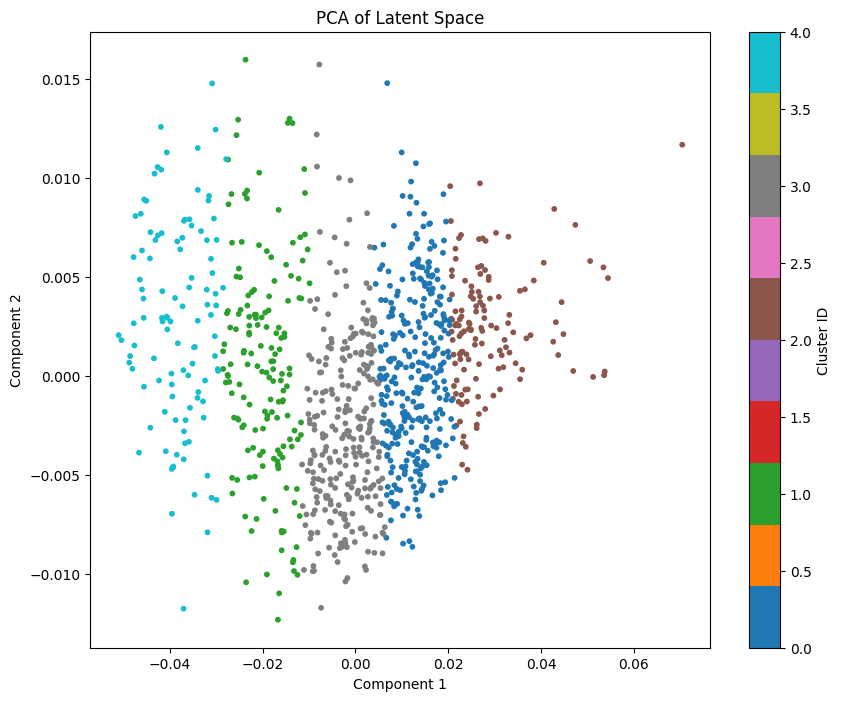

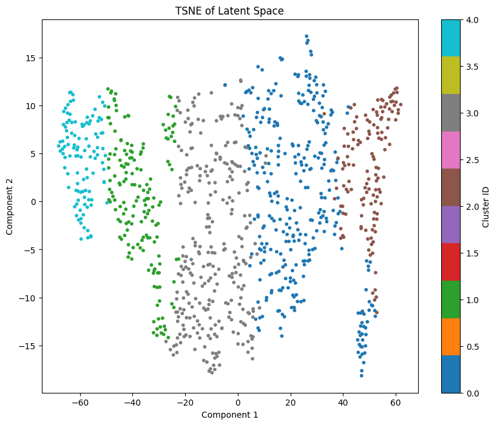

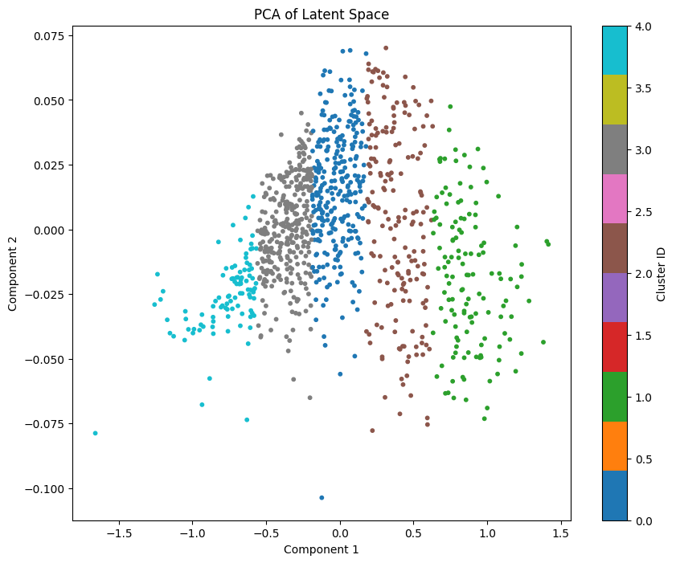

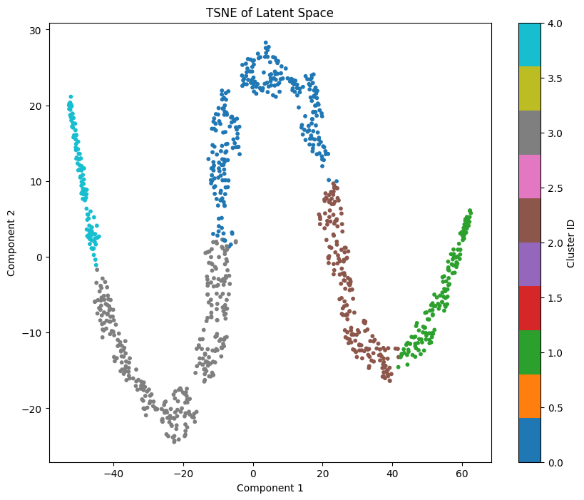

```python
vae_16, history_16 = train_vae(16)
vae_32, history_32 = train_vae(32)

# For latent_dim=16
latents_16 = extract_latents(vae_16, x_train_exp)
labels_16, _ = cluster_latents(latents_16)

# For latent_dim=32
latents_32 = extract_latents(vae_32, x_train_exp)
labels_32, _ = cluster_latents(latents_32)

visualize_latent_space(latents_16, labels_16, method='pca')
visualize_latent_space(latents_16, labels_16, method='tsne')

visualize_latent_space(latents_32, labels_32, method='pca')
visualize_latent_space(latents_32, labels_32, method='tsne')
```

### Discuss:

- What do you notice about the reconstruction performance between the different models? Why are there differences?
- Do you notice differences in images between different clusters? Is the latent space organized differently between models?
- Are the PCA or t-SNE plots different between models? Why or why not?

# Part 4: Cluster and interpolate [2 pts]

## For each model trained in Part 2:

- Encode the images with lowest and highest PCA1 values.
- Interpolate between these two latent vectors, computing the latent vectors for seven evenly spaced points in between.
- Decode and visualize each of these vectors, labeling the interpolation value (between 0 and 1) of each. Include the original and reconstructed images in the visualization.
- Repeat this process for PCA2, t-SNE1, t-SNE2, and one of the dimensions from the latent space.

```python
def interpolate_visualize(vae, points, steps=7, title="Latent Interpolation"):
  interpolated = []
  for alpha in np.linspace(0, 1, steps):
    z = (1 - alpha) * points[0] + alpha * points[1]
    interpolated.append(z)
  interpolated = np.array(interpolated)
  decoded = vae.decoder(interpolated).numpy()

  plt.figure(figsize=(20, 15))
  for i, img in enumerate(decoded):
    plt.subplot(1, steps, i + 1)
    plt.imshow(img.squeeze(), cmap='gray')
    plt.title(f"{i/(steps-1):.2f}")
    plt.axis('off')
  plt.suptitle(title)
  plt.show()
```

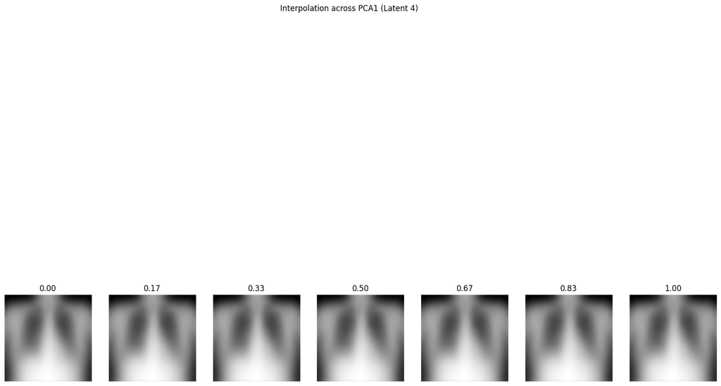

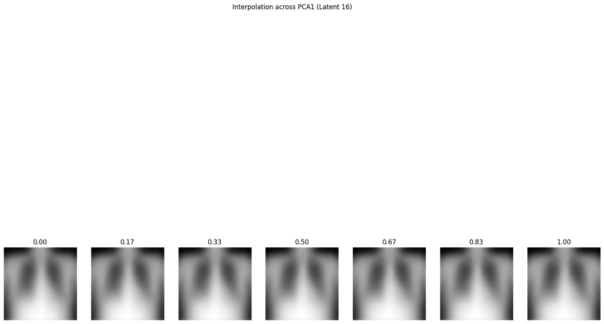

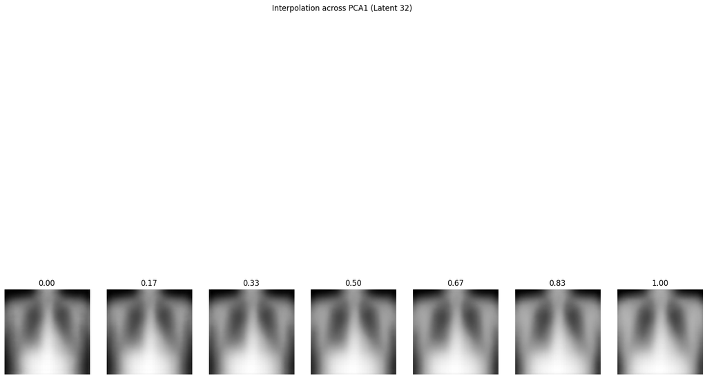

```python
# VAE 4
pca_4 = PCA(n_components=2).fit_transform(latents_4)
low_idx_4 = np.argmin(pca_4[:, 0])
high_idx_4 = np.argmax(pca_4[:, 0])
interpolate_visualize(vae_4, [latents_4[low_idx_4], latents_4[high_idx_4]], title="Interpolation across PCA1 (Latent 4)")

# VAE 16
pca_16 = PCA(n_components=2).fit_transform(latents_16)
low_idx_16 = np.argmin(pca_16[:, 0])
high_idx_16 = np.argmax(pca_16[:, 0])
interpolate_visualize(vae_16, [latents_16[low_idx_16], latents_16[high_idx_16]], title="Interpolation across PCA1 (Latent 16)")

# VAE 32
pca_32 = PCA(n_components=2).fit_transform(latents_32)
low_idx_32 = np.argmin(pca_32[:, 0])
high_idx_32 = np.argmax(pca_32[:, 0])
interpolate_visualize(vae_32, [latents_32[low_idx_32], latents_32[high_idx_32]], title="Interpolation across PCA1 (Latent 32)")
```

### Discuss:

- Do you notice any interesting image features or patterns that seem to be described by any of these interpolation dimensions?
- Are there any notable difference between them?
- Describe the differences between each model.

```python
!pip install
!jupyter nbconvert --to html "/content/drive/MyDrive/QBIO465/SEB QBIO465 HW9.ipynb"
```

[output not shown]

[output cut: 137 more lines]

[output not shown]